# 2-ggplot

```r
suppressPackageStartupMessages(library(dplyr))
suppressPackageStartupMessages(library(ggplot2))
library(GGally)
library(ggthemes)
library(readr)
library(tidyr)
library(tibble)
```

# Text labels.

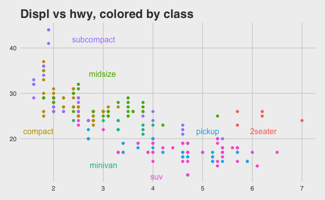

```r
library(directlabels)
library(viridis)
mpg %>%
  ggplot(aes(displ, hwy, colour = class)) +
    geom_point(show.legend = FALSE) +
    geom_dl(aes(label = class), method = "smart.grid") +
    theme_fivethirtyeight() +
    ggtitle("Displ vs hwy, colored by class")
```

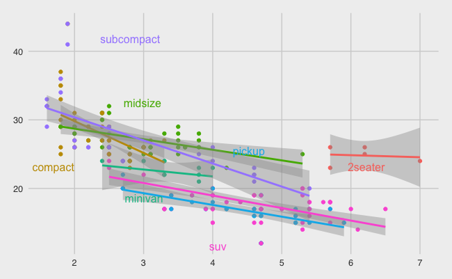

```r
mpg %>%
  ggplot(mapping = aes(x = displ, y = hwy, color = class)) +
    geom_point(show.legend = FALSE) +
    geom_smooth(method = lm, show.legend = FALSE) +
    geom_dl(aes(label = class), method = "smart.grid") +
    theme_fivethirtyeight()
```

```r
NA
```

# Using **annotate()**

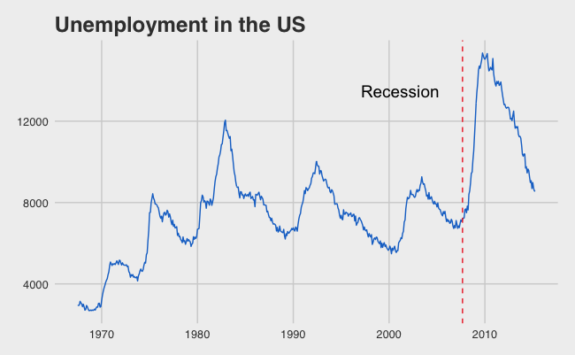

```r
library(lubridate)
depression_day = as.numeric(as.Date(ymd("2007-09-01")))
library(lubridate)
economics %>%
  ggplot(mapping = aes(x = date, y = unemploy)) +
    geom_line(color = "dodgerblue3") +
    theme_fivethirtyeight() +
    ggtitle("Unemployment in the US") +
    annotate("text", x = ymd("2001-03-01"), y = 13500, label = "Recession", size = 5) +
    geom_vline(xintercept = depression_day, linetype = 2, color = "firebrick2")
```

# Changing the groupping of the plotting

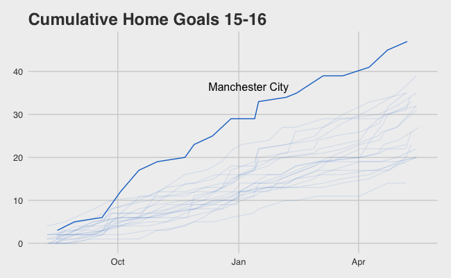

```r
foot <- read_csv("/Users/david_salazarv/Desktop/R Folder/English Premier League/EP-1516.csv",
    col_types = cols(Date = col_date(format = "%d/%m/%y")))
foot %>%
  select(2:8) %>%
  gather(key = 'h', value = "team", 2:3) %>%
  filter(h == 'HomeTeam') %>%
  group_by(team) %>%
  mutate(goals = cumsum(FTHG)) %>%
  arrange(desc(goals)) %>%
  group_by(team) %>%
  mutate(man_city = ifelse(team == "Man City","Manchester City","")) %>%
  ggplot(mapping = aes(x = Date, y = goals)) +
    geom_line(aes(group = team, alpha = factor(man_city)), colour = "dodgerblue3", show.legend = FALSE) +
    geom_dl(aes(label = factor(man_city)), method = "smart.grid") +
    theme_fivethirtyeight() +
    scale_colour_fivethirtyeight() +
    ggtitle("Cumulative Home Goals 15-16")
```

# Maps

Now, let’s learn how to do some maps!

```r
library(sp)
library(maptools)
library(haven)
ohsCol2 <- readShapeSpatial("/Users/david_salazarv/Desktop/R Folder/COL_adm/COL_adm1.shp")
ohsColI2 <- fortify(ohsCol2)
grupo2 <- data.frame(id = unique(ohsColI2[ , c("id")]))
(ohsColI2 <- as_tibble(ohsColI2))
```

```
# A tibble: 148,587 x 7
        long       lat order  hole  piece    id  group
       <dbl>     <dbl> <int> <lgl> <fctr> <chr> <fctr>
1  -69.43138 -1.078474     1 FALSE      1     0    0.1
2  -69.42591 -1.096313     2 FALSE      1     0    0.1
3  -69.42345 -1.104404     3 FALSE      1     0    0.1
4  -69.41992 -1.111588     4 FALSE      1     0    0.1
5  -69.41006 -1.131676     5 FALSE      1     0    0.1
6  -69.39285 -1.148357     6 FALSE      1     0    0.1
7  -69.37515 -1.173309     7 FALSE      1     0    0.1
8  -69.37321 -1.193295     8 FALSE      1     0    0.1
9  -69.37473 -1.205892     9 FALSE      1     0    0.1
10 -69.37823 -1.235153    10 FALSE      1     0    0.1
# ... with 148,577 more rows
```

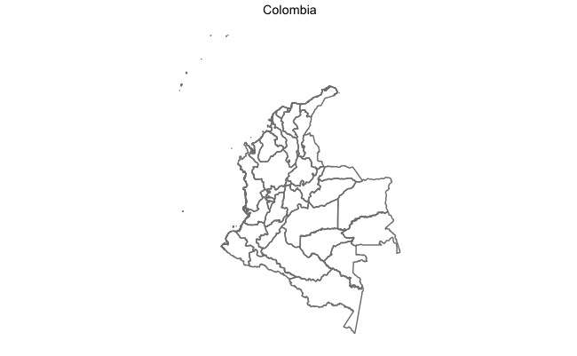

```r
ggplot(ohsColI2, aes(long, lat)) +
  geom_polygon(aes(group = group), colour = "grey50", fill = NA) +
  coord_quickmap() +
  ggtitle("Colombia") +
  theme_map()
```

```r
depto <- read_dta("/Users/david_salazarv/Desktop/Stata Folder/trans.dta")
depto %>%
  arrange(id)
```

```
# A tibble: 33 x 2
   cdigodane    id
       <int> <int>
1         91     1
2          5     2
3         81     3
4          8     4
5         18     5
6         19     6
7         20     7
8         27     8
9         23     9
10        95    10
# ... with 23 more rows
```

```r
as_tibble(ohsColI2)
```

```
# A tibble: 148,587 x 7
        long       lat order  hole  piece    id  group
       <dbl>     <dbl> <int> <lgl> <fctr> <chr> <fctr>
1  -69.43138 -1.078474     1 FALSE      1     0    0.1
2  -69.42591 -1.096313     2 FALSE      1     0    0.1
3  -69.42345 -1.104404     3 FALSE      1     0    0.1
4  -69.41992 -1.111588     4 FALSE      1     0    0.1
5  -69.41006 -1.131676     5 FALSE      1     0    0.1
6  -69.39285 -1.148357     6 FALSE      1     0    0.1
7  -69.37515 -1.173309     7 FALSE      1     0    0.1
8  -69.37321 -1.193295     8 FALSE      1     0    0.1
9  -69.37473 -1.205892     9 FALSE      1     0    0.1
10 -69.37823 -1.235153    10 FALSE      1     0    0.1
# ... with 148,577 more rows
```

```r
total <- ohsColI2 %>%
  mutate(id = as.integer(id)) %>%
  left_join(depto, by = "id") %>%
  as_tibble()
total
```

```
# A tibble: 148,587 x 8
        long       lat order  hole  piece    id  group cdigodane
       <dbl>     <dbl> <int> <lgl> <fctr> <int> <fctr>     <int>
1  -69.43138 -1.078474     1 FALSE      1     0    0.1        NA
2  -69.42591 -1.096313     2 FALSE      1     0    0.1        NA
3  -69.42345 -1.104404     3 FALSE      1     0    0.1        NA
4  -69.41992 -1.111588     4 FALSE      1     0    0.1        NA
5  -69.41006 -1.131676     5 FALSE      1     0    0.1        NA
6  -69.39285 -1.148357     6 FALSE      1     0    0.1        NA
7  -69.37515 -1.173309     7 FALSE      1     0    0.1        NA
8  -69.37321 -1.193295     8 FALSE      1     0    0.1        NA
9  -69.37473 -1.205892     9 FALSE      1     0    0.1        NA
10 -69.37823 -1.235153    10 FALSE      1     0    0.1        NA
# ... with 148,577 more rows
```

```r
desarrollo <- read_dta("/Users/david_salazarv/Downloads/Desarrollo.dta")
d2 <- desarrollo %>%
  group_by(departam) %>%
  summarise(ing_per_capita = mean(ingresos_hogar_jefe)) %>%
  arrange(departam)
d2
```

```
# A tibble: 29 x 2
   departam ing_per_capita
      <int>          <dbl>
1         5      1091704.0
2         8       686628.4
3        11       872260.4
4        13       562415.1
5        15       654817.9
6        17       821821.6
7        19       367892.3
8        20       625414.5
9        23       630330.3
10       25       836275.2
# ... with 19 more rows
```

```r
porfin <- total %>%
  left_join(d2, by = c("cdigodane"="departam"))
porfin <- porfin %>%
  arrange(ing_per_capita) %>%
  mutate(id = as.character(id))
porfin
```

```
# A tibble: 148,587 x 9
       long      lat order  hole  piece    id  group cdigodane ing_per_capita
      <dbl>    <dbl> <int> <lgl> <fctr> <chr> <fctr>     <int>          <dbl>
1  -74.6950 5.752699     1 FALSE      1     6    6.1        19       367892.3
2  -74.6847 5.751001     2 FALSE      1     6    6.1        19       367892.3
3  -74.6766 5.758399     3 FALSE      1     6    6.1        19       367892.3
4  -74.6754 5.746299     4 FALSE      1     6    6.1        19       367892.3
5  -74.6731 5.739900     5 FALSE      1     6    6.1        19       367892.3
6  -74.6766 5.738801     6 FALSE      1     6    6.1        19       367892.3
7  -74.6823 5.729001     7 FALSE      1     6    6.1        19       367892.3
8  -74.6835 5.725001     8 FALSE      1     6    6.1        19       367892.3
9  -74.6852 5.717500     9 FALSE      1     6    6.1        19       367892.3
10 -74.6789 5.710499    10 FALSE      1     6    6.1        19       367892.3
# ... with 148,577 more rows
```

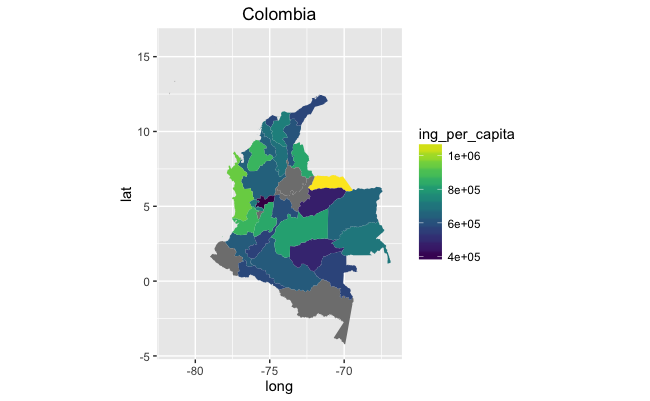

[figure not shown]

```r
library(viridis)
porfin %>%
ggplot(aes(long, lat, group = group)) +
  geom_polygon(aes(fill = ing_per_capita)) +
  coord_quickmap() +
  ggtitle("Colombia") +
  scale_fill_viridis()
```

# Displaying uncertainty

i.e., you have a variable and standard errors. How to plot it? If the variable takes discrete values, pointrange. If the variable is continuous, smooth.

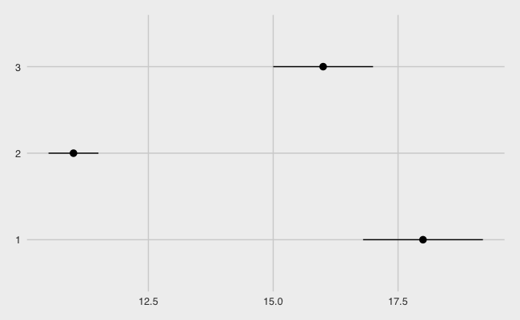

```r
y <- c(18, 11, 16)
df <- data.frame(x = 1:3, y = y, se = c(1.2, 0.5, 1.0))
ggplot(df, aes(factor(x), y, ymin = y - se, ymax = y + se)) +
  geom_pointrange() +
  coord_flip() +
  theme_fivethirtyeight()
```

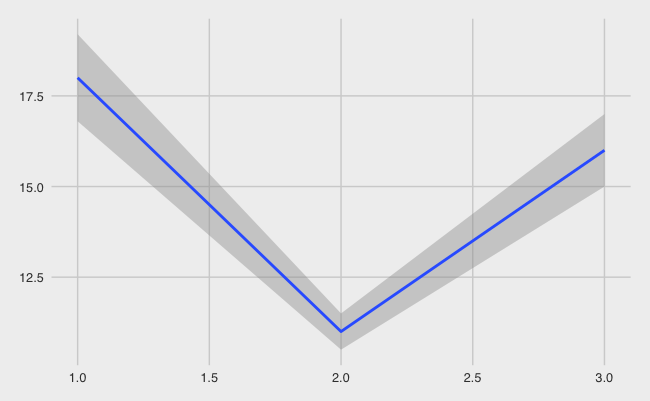

```r
ggplot(df, aes(x, y, ymin = y - se, ymax = y + se)) +
  geom_smooth(stat = "identity") +
  theme_fivethirtyeight()
```

# Aggregated data

When you have aggregated data where each row in the dataset represents multiple observations, you need some way to take into account the weighting variable. For example, each row does not represent the same number of people.

If the number of observations is small, you can map the weighting varibale to the aesthetic size in a scatterplot.

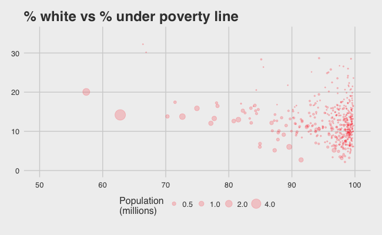

```r
ggplot(midwest, aes(percwhite, percbelowpoverty)) +
  geom_point(aes(size = poptotal / 1e6), alpha = 0.2, color = "firebrick1") +
  scale_size_area("Population\n(millions)", breaks = c(0.5, 1, 2, 4)) +
  coord_cartesian(xlim = c(50, 100), ylim = c(0,35)) +
  theme_fivethirtyeight() +
  ggtitle("% white vs % under poverty line")
```

The old ’merica that, sadly, won’t come back: small white towns and a couple of cosmopolitan enclaves.

The other alternative is to tell a regression to weight the different observations.

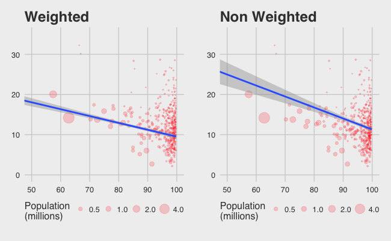

```r
library(gridExtra)
weighted <- ggplot(midwest, aes(percwhite, percbelowpoverty)) +
  geom_point(aes(size = poptotal / 1e6), alpha = 0.2, color = "firebrick1") +
  geom_smooth(aes(weight = poptotal), method = lm, size = 1) +
  scale_size_area("Population\n(millions)", breaks = c(0.5, 1, 2, 4)) +
  coord_cartesian(xlim = c(50, 100), ylim = c(0,35)) +
  ggtitle("Weighted") +
  theme_fivethirtyeight()
non_weighted <- ggplot(midwest, aes(percwhite, percbelowpoverty)) +
  geom_point(aes(size = poptotal / 1e6), alpha = 0.2, color = "firebrick1") +
  geom_smooth(method = lm, size = 1) +
  scale_size_area("Population\n(millions)", breaks = c(0.5, 1, 2, 4)) +
  coord_cartesian(xlim = c(50, 100), ylim = c(0,35)) +
  theme_fivethirtyeight() +
  ggtitle("Non Weighted")
grid.arrange(weighted, non_weighted, nrow = 1)
```

```r
"from = http://stackoverflow.com/questions/36659813/how-do-i-add-an-axis-label-on-an-axis-tick-mark-using-ggplot2-in-r-similar-to-t"
```

```
[1] "from = http://stackoverflow.com/questions/36659813/how-do-i-add-an-axis-label-on-an-axis-tick-mark-using-ggplot2-in-r-similar-to-t"
```

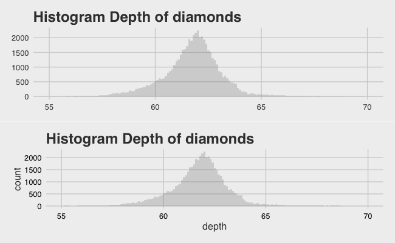

```r
theme_fivethirtyeight_mod <- function (base_size = 12, base_family = "sans") {
(theme_foundation(base_size = base_size, base_family = base_family) +
 theme(line = element_line(colour = "black"), rect = element_rect(fill = ggthemes_data$fivethirtyeight["ltgray"], linetype = 0, colour = NA), text = element_text(colour = ggthemes_data$fivethirtyeight["dkgray"]),
       axis.text = element_text(color = 'black'), axis.ticks = element_blank(), axis.line = element_blank(),
       legend.title = element_blank(), legend.background = element_rect(fill="gray90", size=.5, linetype="dotted"),
       legend.position = "bottom", legend.direction = "horizontal", legend.box = "vertical",
       panel.grid = element_line(colour = NULL), panel.grid.major = element_line(colour = ggthemes_data$fivethirtyeight["medgray"]),
       panel.grid.minor = element_blank(), plot.title = element_text(hjust = 0, size = rel(1.5), face = "bold"),
       plot.margin = unit(c(1, 1, 1, 1), "lines"), strip.background = element_rect()))
}
g1 <- ggplot(diamonds, aes(depth)) +
  geom_histogram(binwidth = 0.1, alpha = 0.2) +
  xlim(55, 70) +
  theme_fivethirtyeight() +
  ggtitle("Histogram Depth of diamonds")
g2 <- ggplot(diamonds, aes(depth)) +
  geom_histogram(binwidth = 0.1, alpha = 0.2) +
  xlim(55, 70) +
  theme_fivethirtyeight_mod() +
  ggtitle("Histogram Depth of diamonds")
grid.arrange(g1, g2)
```

When publishing figures, don’t forget to include information about important parameters (like bin width) in the caption.

If you want to compare the distribution between groups, you have a few options: * Show small multiples of the histogram, facet wrap( ̃ var). * Use colour and a frequency polygon, geom freqpoly() . * Use a “conditional density plot”, geom histogram(position = “fill”).

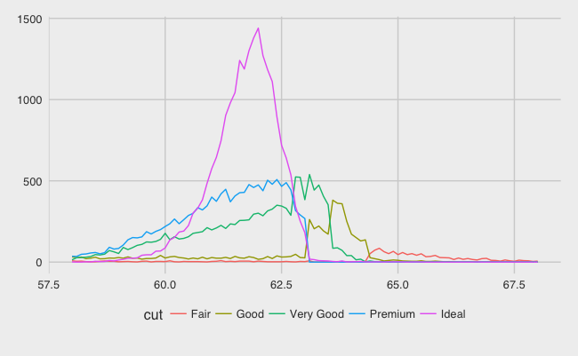

```r
ggplot(diamonds, aes(depth)) +
  geom_freqpoly(aes(colour = cut), binwidth = 0.1, na.rm = TRUE) + xlim(58, 68) +
  theme_fivethirtyeight()
```

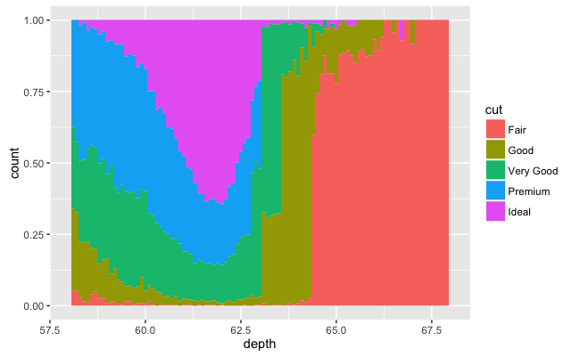

```r
ggplot(diamonds, aes(depth)) +
geom_histogram(aes(fill = cut), binwidth = 0.1, position = "fill",
na.rm = TRUE) +
xlim(58, 68)
```

Or use a density estimation:

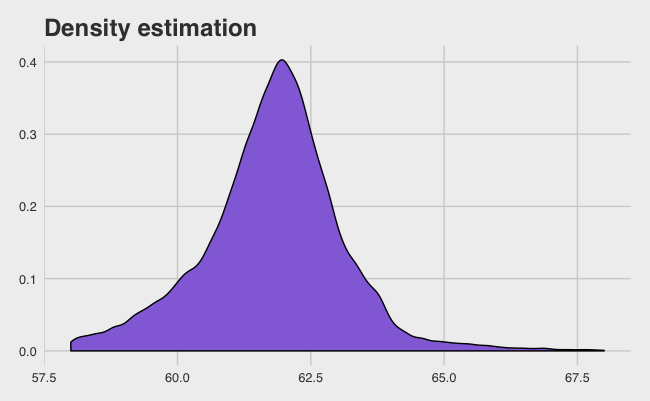

```r
ggplot(diamonds, aes(depth)) +
  geom_density(na.rm = TRUE, fill = "mediumpurple") + xlim(58, 68) +
  theme_fivethirtyeight() +
  ggtitle("Density estimation")
```

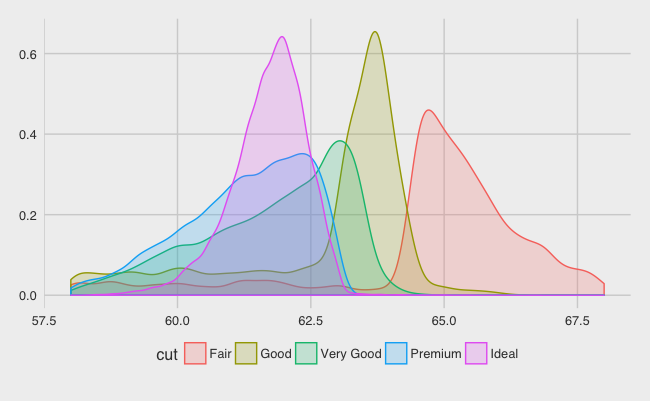

```r
ggplot(diamonds, aes(depth, fill = cut, colour = cut)) + geom_density(alpha = 0.2, na.rm = TRUE) +
xlim(58, 68) + theme_fivethirtyeight()
```

In the last plot, we lose information about the relative size of each group, as every density integrates to 1.

# Overcoming overplotting

For larger datasets with more overplotting, you can use alpha blending (transparency) to make the points transparent. If you specify alpha as a ratio, the denominator gives the number of points that must be overplotted to give a solid colour. Additionally, you can jitter the points.

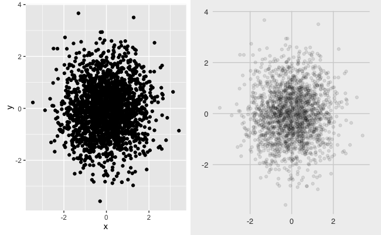

```r
df <- data.frame(x = rnorm(2000), y = rnorm(2000))
g1 <- df %>%
  ggplot(mapping = aes(x = x, y = y)) +
    geom_jitter()
g2 <- df %>%
  ggplot(mapping = aes(x = x, y = y)) +
    geom_jitter(alpha = 1/10) +
    theme_fivethirtyeight()
grid.arrange(g1, g2, nrow = 1)
```

Bin the points and count the number in each bin, then visualise that count. For binning with hexagons and fill them according to the number of counts.

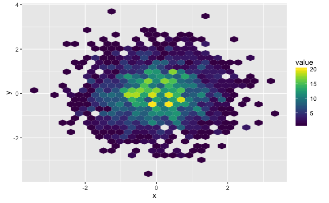

```r
library(viridis)
df %>%
  ggplot(mapping = aes(x = x, y = y)) +
    geom_hex() +
    scale_fill_viridis()
```

# Statistical transformations

When binning, we count the number of observations in each bin; but what if we want to count something else? To do a barplot that represents the average price per color:

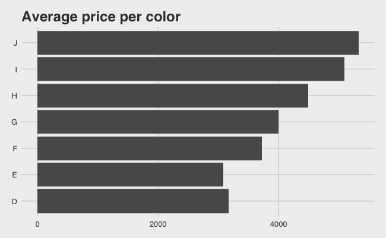

```r
ggplot(diamonds, aes(color, price)) +
  geom_bar(stat = "summary_bin", fun.y = mean) +
  coord_flip() +
  theme_fivethirtyeight() +
  ggtitle("Average price per color")
```